# California Housing Price Prediction: A case study

Moving beyond linearity

Group 1

2026-05-18

**Team Members:** Collins Oduor - 219858 | Michelle Kalevela - 222647 | Diana Otieno - 222658 | Methuselah Amtany - 223930 | Wesley Gathua - 223347 | Dennis Koome - 193582 | Wendy Oira - 221007 | Nehema Mburuki - 190546

# 1 Introduction & Objectives

This project applies the nonparametric and semi-parametric regression techniques to the California Housing dataset. The central thesis is that the relationship between housing price and its predictors is **inherently nonlinear and spatially interactive**, a claim we test rigorously by comparing a full ladder of model families.

**Research Questions**

1. Can ensemble nonlinear models (Random Forest, XGBoost, Neural Network) predict house prices more accurately than classical approaches? What are the most important nonlinear interactions between location and income?
2. Which model family — **GNPR** (GAM, Kernel/Local Regression, Splines, Step Functions, Polynomial) vs. **Parametric** (Linear, Ridge) vs. **Machine Learning** (RF, XGBoost, NN) — provides the best predictive performance?

# 2 Package Installation & Loading

```r
required_pkgs <- c(
  "tidyverse", "caret", "randomForest", "xgboost",
  "mgcv", "splines", "np", "corrplot", "gridExtra",
  "Metrics", "neuralnet", "ggplot2", "viridis", "scales",
  "pdp", "vip", "spdep", "sf", "kableExtra", "GGally",
  "patchwork", "ggrepel", "finalfit", "spatialreg", "spdep",
  "sf", "spam", "ranger", "GWmodel", "tmap"
)

for (pkg in required_pkgs) {
  if(!(pkg %in% installed.packages())) {
    install.packages(pkg)
  }

  library(pkg, character.only = T)
}

# Global ggplot theme
theme_set(theme_minimal(base_size = 12) +
            theme(plot.title = element_text(face = "bold", size = 13),
                  plot.subtitle = element_text(color = "grey40")))
```

# 3 Constants and Utility functions

```r
columns_all <- c("longitude", "latitude", "housing_median_age",
                 "total_rooms", "total_bedrooms", "population",
                 "households", "median_income", "median_house_value")
columns_non_spatial <- c("housing_median_age","total_rooms",
                         "total_bedrooms", "population",
                         "households", "median_income",
                         "median_house_value")
independent_columns_all <- c("longitude", "latitude",
                             "housing_median_age","total_rooms",
                             "total_bedrooms", "population",
                             "households", "median_income")
independent_columns_non_spatial <- c("housing_median_age",
                                     "total_rooms", "total_bedrooms",
                                     "population", "households",
                                     "median_income")

set.seed(42)
```

```r
calc_metrics <- function(actual, predicted, model_name) {
  rmse_val <- rmse(actual, predicted)
  mae_val  <- mae(actual, predicted)
  r2_val   <- cor(actual, predicted)^2
  tibble(
    Model = model_name,
    RMSE  = round(rmse_val, 2),
    MAE   = round(mae_val,  2),
    R2    = round(r2_val,   4)
  )
}

# Storage for predictions and metrics
all_metrics <- list()
all_preds   <- list()
```

# 4 Data Loading & Initial Inspection

```r
data <- read.csv("~/Downloads/cal_housing.data", header = FALSE)

colnames(data) <- columns_all

cat("Dimensions: ", dim(data), "\n")
```

```
#> Dimensions:  20640 9
```

```r
cat("Missing values: ", sum(is.na(data)), "\n")
```

```
#> Missing values:  0
```

```r
head(data, 6)
```

|  | longitude | latitude | housing_median_age | total_rooms | total_bedrooms | population | households | median_income | median_house_value |
| --- | --- | --- | --- | --- | --- | --- | --- | --- | --- |
| 1 | -122.23 | 37.88 | 41 | 880 | 129 | 322 | 126 | 8.3252 | 452600 |
| 2 | -122.22 | 37.86 | 21 | 7099 | 1106 | 2401 | 1138 | 8.3014 | 358500 |
| 3 | -122.24 | 37.85 | 52 | 1467 | 190 | 496 | 177 | 7.2574 | 352100 |
| 4 | -122.25 | 37.85 | 52 | 1274 | 235 | 558 | 219 | 5.6431 | 341300 |
| 5 | -122.25 | 37.85 | 52 | 1627 | 280 | 565 | 259 | 3.8462 | 342200 |
| 6 | -122.25 | 37.85 | 52 | 919 | 213 | 413 | 193 | 4.0368 | 269700 |

```r
cat("Summary of data \n")
```

```
#> Summary of data
```

```r
t(summary(data))
```

```
#>
#>   longitude        Min.   :-124.3    1st Qu.:-121.8    Median :-118.5
#>    latitude        Min.   :32.54     1st Qu.:33.93     Median :34.26
#> housing_median_age Min.   : 1.00     1st Qu.:18.00     Median :29.00
#>  total_rooms       Min.   :    2     1st Qu.: 1448     Median : 2127
#> total_bedrooms     Min.   :   1.0    1st Qu.: 295.0    Median : 435.0
#>   population       Min.   :    3     1st Qu.:  787     Median : 1166
#>   households       Min.   :   1.0    1st Qu.: 280.0    Median : 409.0
#> median_income      Min.   : 0.4999   1st Qu.: 2.5634   Median : 3.5348
#> median_house_value Min.   : 14999    1st Qu.:119600    Median :179700
#>
#>   longitude        Mean   :-119.6    3rd Qu.:-118.0    Max.   :-114.3
#>    latitude        Mean   :35.63     3rd Qu.:37.71     Max.   :41.95
#> housing_median_age Mean   :28.64     3rd Qu.:37.00     Max.   :52.00
#>  total_rooms       Mean   : 2636     3rd Qu.: 3148     Max.   :39320
#> total_bedrooms     Mean   : 537.9    3rd Qu.: 647.0    Max.   :6445.0
#>   population       Mean   : 1425     3rd Qu.: 1725     Max.   :35682
#>   households       Mean   : 499.5    3rd Qu.: 605.0    Max.   :6082.0
#> median_income      Mean   : 3.8707   3rd Qu.: 4.7432   Max.   :15.0001
#> median_house_value Mean   :206856    3rd Qu.:264725    Max.   :500001
```

```r
cat("\nUnique values per column \n")
```

```
#>
#> Unique values per column
```

```r
t(sapply(data, function(x) length(unique(x))))
```

```
#>      longitude latitude housing_median_age total_rooms total_bedrooms
#> [1,]       844      862                 52        5926           1928
#>      population households median_income median_house_value
#> [1,]       3888       1815         12928               3842
```

# 5 Exploratory Data Analysis

## 5.1 Distributions of All Variables

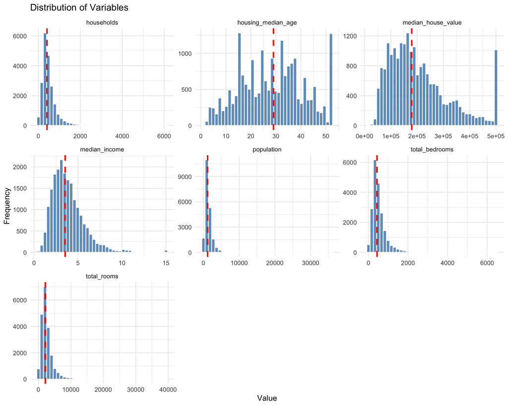

```r
# 1. Calculating the medians for each variable first
medians_data <- data %>%
  select(-c(longitude, latitude)) %>%
  pivot_longer(everything(), names_to = "variable", values_to = "value") %>%
  group_by(variable) %>%
  summarize(median_val = median(value, na.rm = TRUE))

# 2. Pivoting the main data
data_long <- data %>%
  select(-c(longitude, latitude)) %>%
  pivot_longer(everything(), names_to = "variable", values_to = "value")

# 3. Plotting then adding the medians_data to the geom_vline
ggplot(data_long, aes(x = value)) +
  geom_histogram(bins = 40, fill = "steelblue", color = "white", alpha = 0.8) +
  geom_vline(data = medians_data, aes(xintercept = median_val), color = "red", linetype = "dashed", size = 1) +
  facet_wrap(~variable, scales = "free") +
  theme_minimal() +
  labs(title = "Distribution of Variables", x = "Value", y = "Frequency")
```

- The numeric features are skewed to the right apart from housing_median_age which is bi-modal.

```r
cat("The highest value for housing median age is:", max(data$housing_median_age), "\n")
```

```
#> The highest value for housing median age is: 52
```

```r
cat("The highest median house value is:", max(data$median_house_value), "\n")
```

```
#> The highest median house value is: 500001
```

```r
cat("The highest median income is:", max(data$median_income), "\n")
```

```
#> The highest median income is: 15.0001
```

```r
# Creating a clean, uncapped dataset
clean_data <- data %>%
  filter(median_house_value < 500000) %>%
  filter(housing_median_age < 52) %>%
  filter(median_income < 15)

# Checking # of lost rows
print(paste("Original rows:", nrow(data)))
```

```
#> [1] "Original rows: 20640"
```

```r
print(paste("Cleaned rows:", nrow(clean_data)))
```

```
#> [1] "Cleaned rows: 18553"
```

- After filtering, 2087 rows of data were lost. A sacrifice for statistical accuracy.

## 5.2 Correlation Structure

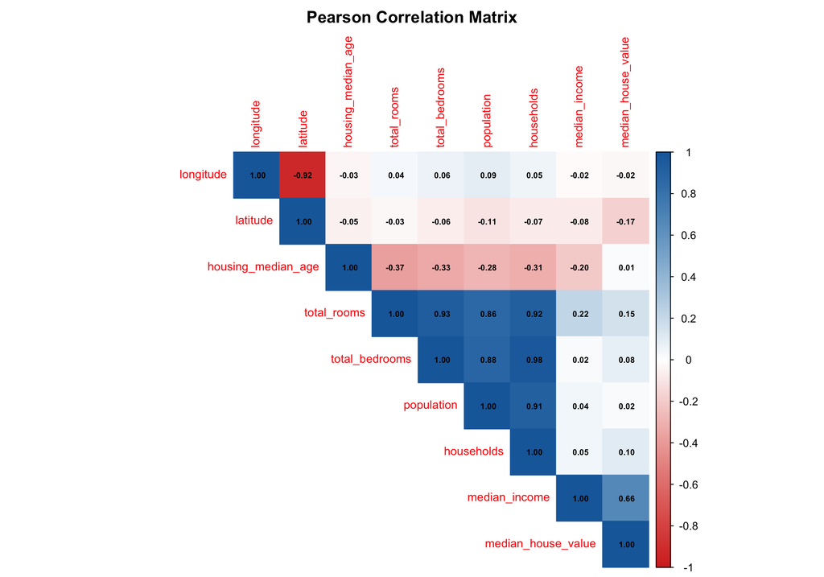

```r
cor_matrix <- cor(clean_data, use = "complete.obs")
corrplot(
  cor_matrix,
  method      = "color",
  type        = "upper",
  tl.cex      = 0.85,
  addCoef.col = "black",
  number.cex  = 0.60,
  col         = colorRampPalette(c("#d73027","white","#1a6aaa"))(200),
  title       = "Pearson Correlation Matrix",
  mar         = c(0, 0, 2, 0)
)
```

- There is a very high correlation between total bedrooms, population, households and total rooms. Median income has a high correlation with median house value.

```r
# 1. Creating categorical dependent variable using existing 'clean_data'
summary_data <- clean_data %>%
  mutate(
    house_value_group = ntile(median_house_value, 4) %>%
      factor(labels = c("Low", "Medium", "High", "Very High"))
  )

# 2. Defining dependent and explanatory variables
dependent <- "house_value_group"

# Selecting all columns except targets and geographical coordinates
explanatory <- summary_data %>%
  select(-median_house_value, -house_value_group, -longitude, -latitude) %>%
  names()

# 3. Creating the summary factorlist
table1 <- summary_data %>%
  summary_factorlist(
    dependent = dependent,
    explanatory = explanatory,
    p = TRUE,              # Includes p-values for statistical differences
    cont = "median",       # Used median for continuous variables (handles skewness well)
    column = TRUE,
    total_col = TRUE,
    na_include = TRUE
  )

# 4. Rendering as a formatted HTML table
table1 %>%
  kbl(
    caption = "Table 1: Summary Statistics by House Value Quartile",
    align = "lcccccc",
    booktabs = FALSE
  ) %>%
  kable_styling(
    bootstrap_options = c("striped", "bordered", "hover"),
    full_width = FALSE
  ) %>%
  row_spec(0, bold = TRUE)
```

Table 1: Summary Statistics by House Value Quartile

| label | levels | Low | Medium | High | Very High | Total | p |
| --- | --- | --- | --- | --- | --- | --- | --- |
| housing_median_age | Median (IQR) | 28.0 (18.0 to 36.0) | 26.0 (16.0 to 36.0) | 28.0 (18.0 to 35.0) | 27.0 (18.0 to 36.0) | 27.0 (17.0 to 36.0) | <0.001 |
| total_rooms | Median (IQR) | 1802.0 (1228.0 to 2612.0) | 2037.0 (1400.2 to 3079.5) | 2221.5 (1529.2 to 3241.8) | 2550.5 (1755.0 to 3770.8) | 2142.0 (1455.0 to 3184.0) | <0.001 |
| total_bedrooms | Median (IQR) | 395.0 (271.0 to 573.0) | 448.0 (303.0 to 666.0) | 461.0 (311.2 to 696.0) | 469.0 (319.0 to 715.8) | 442.0 (300.0 to 659.0) | <0.001 |
| population | Median (IQR) | 1100.0 (733.5 to 1579.0) | 1302.5 (863.0 to 1932.0) | 1265.0 (855.0 to 1872.8) | 1179.0 (808.0 to 1750.5) | 1204.0 (811.0 to 1781.0) | <0.001 |
| households | Median (IQR) | 361.0 (248.5 to 521.0) | 419.0 (287.0 to 616.8) | 434.5 (297.0 to 652.0) | 448.0 (309.0 to 665.8) | 416.0 (284.0 to 614.0) | <0.001 |
| median_income | Median (IQR) | 2.3 (1.8 to 3.0) | 3.2 (2.5 to 4.0) | 3.9 (3.1 to 4.7) | 5.1 (3.9 to 6.2) | 3.5 (2.5 to 4.6) | <0.001 |

- All the variables in the table have p-values less than 0.05 thus proving to be significant.

## 5.3 Geographic Distribution

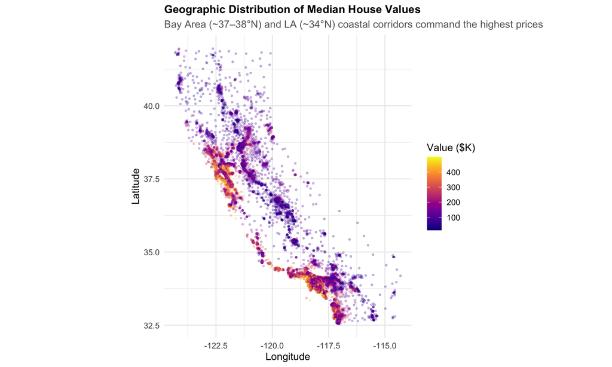

```r
ggplot(clean_data, aes(x = longitude, y = latitude, color = median_house_value / 1e3)) +
  geom_point(alpha = 0.25, size = 0.7) +
  scale_color_viridis(name = "Value ($K)", option = "C", labels = comma) +
  coord_fixed(ratio = 1.3) +
  labs(
    title    = "Geographic Distribution of Median House Values",
    subtitle = "Bay Area (~37–38°N) and LA (~34°N) coastal corridors command the highest prices",
    x = "Longitude", y = "Latitude"
  )
```

- Expensive neighborhoods tend to be geographically grouped together. Additionally, expensive neighborhoods are on the western part of California near the ocean while cheaper houses are located towards the inland side.

## 5.4 Spatial Autocorrelation — Moran’s I Test

```r
spatial_obj <- st_as_sf(clean_data, coords = c("longitude", "latitude"), crs = 4326)
coords <- st_coordinates(spatial_obj)
knn5 <- knn2nb(knearneigh(coords, k = 101))
lw <- nb2listw(knn5, style = "W")

moran_value <- moran.test(clean_data$median_house_value, lw)
cat("Moran's I (median_house_value) :", round(moran_value$estimate["Moran I statistic"], 4), "\n")
```

```
#> Moran's I (median_house_value) : 0.6053
```

```r
cat("p-value                        :", format(moran_value$p.value, scientific = TRUE), "\n")
```

```
#> p-value                        : 0e+00
```

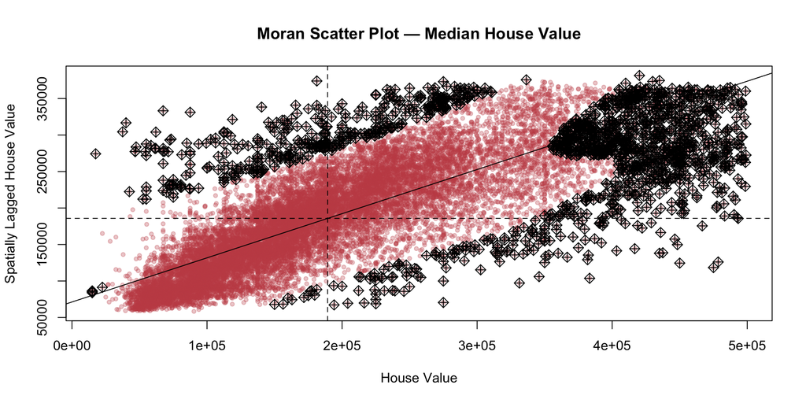

```r
moran.plot(
  clean_data$median_house_value, lw,
  labels = FALSE,
  main   = "Moran Scatter Plot — Median House Value",
  xlab   = "House Value", ylab = "Spatially Lagged House Value",
  pch    = 20, col = rgb(0.77, 0.31, 0.32, 0.3)
)
```

- The Moran’s I value is **statistically significant** (p = 0e+00), confirming strong positive spatial autocorrelation in house values. Nearby block-groups tend to have similar values, underpinning why location features (latitude, longitude) are critical predictors.

## 5.5 Nonlinearity

- Neighborhoods are clustered by income brackets due to economic segregation.

**Conclusion:** Using a standard linear model for prediction here would introduce severe systemic bias. To properly model these data dynamics, it is important to implement non-linear specifications such as polynomial terms, regression splines (B-Splines/Natural Splines) or generalized additive models (GAMs) while simultaneously addressing spatial autocorrelation.

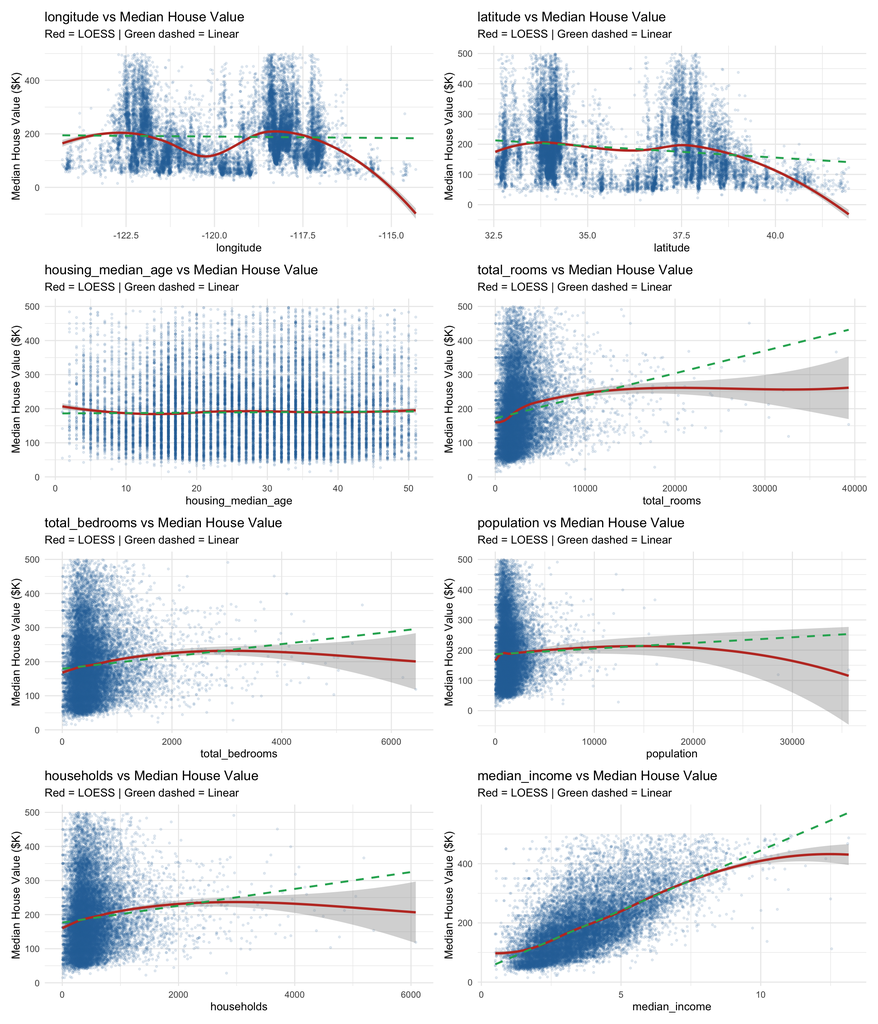

```r
plots <- lapply(independent_columns_all, function(v) {

  ggplot(clean_data, aes(x = .data[[v]], y = median_house_value / 1e3)) +
    geom_point(alpha = 0.12, color = "#2e6da4", size = 0.7) +
    geom_smooth(
      method = "loess",
      color = "#c0392b",
      linewidth = 1.1,
      se = TRUE
    ) +
    geom_smooth(
      method = "lm",
      color = "#27ae60",
      linewidth = 0.9,
      linetype = "dashed",
      se = FALSE
    ) +
    labs(
      title = paste(v, "vs Median House Value"),
      subtitle = "Red = LOESS | Green dashed = Linear",
      x = v,
      y = "Median House Value ($K)"
    ) +

    theme_minimal(base_size = 11)
})

# Combine all 8 plots into a 4x2 grid
wrap_plots(plots, ncol = 2)
```

- The data exhibited a distinct non-linear trend that was poorly captured by the standard Ordinary Least Squares (OLS) model (green-dashed line). The linear model assumed a constant marginal effect:

# 6 Feature Engineering & Preprocessing

```r
data_engineered <- clean_data %>%
  mutate(
    rooms_per_household = total_rooms / households,
    bedrooms_per_room = total_bedrooms / total_rooms,
    population_per_household = population / households
  ) |>
  select(-c(total_rooms, total_bedrooms, population, households))

cat("Feature-engineered dataset dimensions:", dim(data_engineered), "\n")
```

```
#> Feature-engineered dataset dimensions: 18553 8
```

- The data was split into train and test set using a 70:30 ratio.
- The data was also scaled in order for it to be handled smoothly by parametric and neural network models.

```r
train_idx <- createDataPartition(data_engineered$median_house_value, p = 0.7, list = FALSE)

features <- c("longitude", "latitude", "housing_median_age", "median_income",
  "rooms_per_household", "bedrooms_per_room", "population_per_household")

train_raw <- data_engineered[ train_idx, ]
test_raw  <- data_engineered[-train_idx, ]

preproc_all <- preProcess(
  train_raw[, features],
  method = c("center", "scale")
)

train_sc <- predict(preproc_all, train_raw[, features])
train_sc$median_house_value <- train_raw$median_house_value

test_sc <- predict(preproc_all, test_raw[, features])
test_sc$median_house_value <- test_raw$median_house_value

X_train <- train_sc[, features]
y_train <- train_sc$median_house_value
X_test  <- test_sc[, features]
y_test  <- test_sc$median_house_value

cat("Training set size :", nrow(train_sc), "\n")
```

```
#> Training set size : 12990
```

```r
cat("Test set size     :", nrow(test_sc),  "\n")
```

```
#> Test set size     : 5563
```

# 7 Modelling

## 7.1 Multiple Linear Regression (Baseline)

**Theoretical basis:** The standard parametric model assumes:

$$y_i = \beta_0 + \beta_1 x_{i1} + \cdots
+ \beta_p x_{ip} + \varepsilon_i$$

- This imposes linearity and additivity.

```r
lm_formula <- as.formula(
  paste("median_house_value ~", paste(features, collapse = " + "))
)
lm_model <- lm(lm_formula, data = train_sc)

summary(lm_model)
```

```
#>
#> Call:
#> lm(formula = lm_formula, data = train_sc)
#>
#> Residuals:
#>     Min      1Q  Median      3Q     Max
#> -441061  -38664   -9760   28419  350597
#>
#> Coefficients:
#>                          Estimate Std. Error t value Pr(>|t|)
#> (Intercept)              189178.6      528.7  357.79  < 2e-16 ***
#> longitude                -73637.1     1567.0  -46.99  < 2e-16 ***
#> latitude                 -77292.1     1616.2  -47.82  < 2e-16 ***
#> housing_median_age         7021.6      564.3   12.44  < 2e-16 ***
#> median_income             68618.6      772.4   88.83  < 2e-16 ***
#> rooms_per_household        7526.9      629.7   11.95  < 2e-16 ***
#> bedrooms_per_room         20836.0      752.4   27.69  < 2e-16 ***
#> population_per_household  -3763.3      530.0   -7.10 1.31e-12 ***
#> ---
#> Signif. codes:  0 '***' 0.001 '**' 0.01 '*' 0.05 '.' 0.1 ' ' 1
#>
#> Residual standard error: 60260 on 12982 degrees of freedom
#> Multiple R-squared:  0.5998, Adjusted R-squared:  0.5996
#> F-statistic:  2780 on 7 and 12982 DF,  p-value: < 2.2e-16
```

```r
lm_preds <- predict(lm_model, newdata = test_sc)

lm_metrics <- calc_metrics(actual = y_test, predicted = lm_preds, model_name = "Multiple Linear Regression")

all_metrics[[1]] <- lm_metrics
all_preds[["MLR"]] <- lm_preds

print(lm_metrics)
```

```
#> # A tibble: 1 × 4
#>   Model                        RMSE    MAE    R2
#>   <chr>                       <dbl>  <dbl> <dbl>
#> 1 Multiple Linear Regression 61491. 45639. 0.587
```

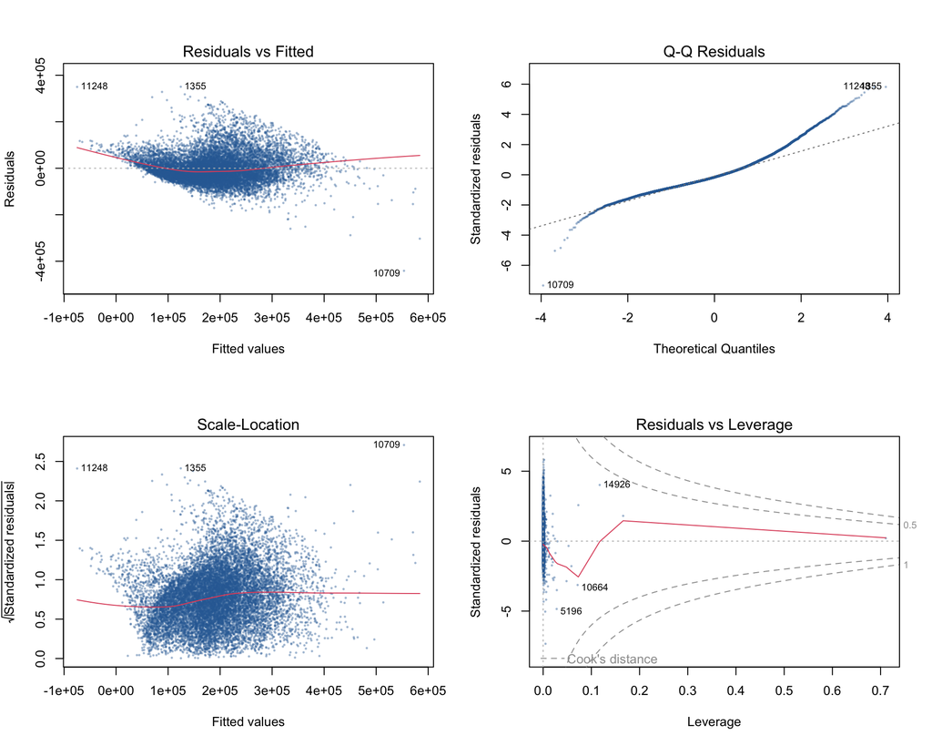

```r
par(mfrow = c(2, 2))
plot(lm_model, pch = 20, cex = 0.4, col = rgb(0.18, 0.42, 0.64, 0.3))
```

```r
par(mfrow = c(1, 1))
```

## 7.2 Polynomial Regression (Degree 3)

**Theoretical basis** Polynomial regression extends the linear model by raising predictors to powers:

$$y_i = \beta_0 + \beta_1 x_i + \beta_2
x_i^2 + \cdots + \beta_d x_i^d + \varepsilon_i$$

- We use **degree 3** (cubic) due to the previously plotted LOESS curve which exhibited a sigmoid shape. With regards to the coordinates (Latitude and Longitude), the 3rd degree aided in 3-dimensional surface in the sense that Geography would also be accounted for. The difference in all this was the housing median age as d was 2. This comes from the well established notion that housing prices parabola shape. New houses are expensive which follows a depreciation as the years go by. On the other hand, old houses are expensive due to the large spaces they tend to have.

```r
poly_model <- lm(
  median_house_value ~
    poly(median_income, 3, raw = FALSE) +   # orthogonal cubic poly
    poly(latitude,      3, raw = FALSE) +
    poly(longitude,     3, raw = FALSE) +
    poly(housing_median_age, 2, raw = FALSE) +
    rooms_per_household + bedrooms_per_room +
    population_per_household,
  data = train_sc
)

summary(poly_model)
```

```
#>
#> Call:
#> lm(formula = median_house_value ~ poly(median_income, 3, raw = FALSE) +
#>     poly(latitude, 3, raw = FALSE) + poly(longitude, 3, raw = FALSE) +
#>     poly(housing_median_age, 2, raw = FALSE) + rooms_per_household +
#>     bedrooms_per_room + population_per_household, data = train_sc)
#>
#> Residuals:
#>     Min      1Q  Median      3Q     Max
#> -307264  -37890   -9489   27774  355697
#>
#> Coefficients:
#>                                             Estimate Std. Error t value
#> (Intercept)                                1.892e+05  5.232e+02 361.577
#> poly(median_income, 3, raw = FALSE)1       7.804e+06  8.862e+04  88.059
#> poly(median_income, 3, raw = FALSE)2      -3.844e+04  6.179e+04  -0.622
#> poly(median_income, 3, raw = FALSE)3      -5.334e+05  5.981e+04  -8.919
#> poly(latitude, 3, raw = FALSE)1           -1.022e+07  2.165e+05 -47.202
#> poly(latitude, 3, raw = FALSE)2            9.974e+05  8.244e+04  12.098
#> poly(latitude, 3, raw = FALSE)3            6.193e+05  7.197e+04   8.605
#> poly(longitude, 3, raw = FALSE)1          -9.852e+06  2.128e+05 -46.301
#> poly(longitude, 3, raw = FALSE)2          -4.604e+05  7.234e+04  -6.364
#> poly(longitude, 3, raw = FALSE)3           5.816e+05  7.792e+04   7.463
#> poly(housing_median_age, 2, raw = FALSE)1  7.822e+05  6.421e+04  12.181
#> poly(housing_median_age, 2, raw = FALSE)2 -3.810e+04  5.980e+04  -0.637
#> rooms_per_household                        7.669e+03  6.245e+02  12.280
#> bedrooms_per_room                          2.031e+04  7.681e+02  26.439
#> population_per_household                  -3.654e+03  5.257e+02  -6.950
#>                                           Pr(>|t|)
#> (Intercept)                                < 2e-16 ***
#> poly(median_income, 3, raw = FALSE)1       < 2e-16 ***
#> poly(median_income, 3, raw = FALSE)2         0.534
#> poly(median_income, 3, raw = FALSE)3       < 2e-16 ***
#> poly(latitude, 3, raw = FALSE)1            < 2e-16 ***
#> poly(latitude, 3, raw = FALSE)2            < 2e-16 ***
#> poly(latitude, 3, raw = FALSE)3            < 2e-16 ***
#> poly(longitude, 3, raw = FALSE)1           < 2e-16 ***
#> poly(longitude, 3, raw = FALSE)2          2.04e-10 ***
#> poly(longitude, 3, raw = FALSE)3          8.97e-14 ***
#> poly(housing_median_age, 2, raw = FALSE)1  < 2e-16 ***
#> poly(housing_median_age, 2, raw = FALSE)2    0.524
#> rooms_per_household                        < 2e-16 ***
#> bedrooms_per_room                          < 2e-16 ***
#> population_per_household                  3.82e-12 ***
#> ---
#> Signif. codes:  0 '***' 0.001 '**' 0.01 '*' 0.05 '.' 0.1 ' ' 1
#>
#> Residual standard error: 59630 on 12975 degrees of freedom
#> Multiple R-squared:  0.6084, Adjusted R-squared:  0.608
#> F-statistic:  1440 on 14 and 12975 DF,  p-value: < 2.2e-16
```

```r
poly_preds <- predict(poly_model, newdata = test_sc)

poly_metrics <- calc_metrics(actual = y_test, predicted = poly_preds, model_name = "Polynomial Regression")

all_metrics[[2]] <- poly_metrics
all_preds[["Poly"]] <- poly_preds

print(poly_metrics)
```

```
#> # A tibble: 1 × 4
#>   Model                   RMSE    MAE    R2
#>   <chr>                  <dbl>  <dbl> <dbl>
#> 1 Polynomial Regression 61105. 45094. 0.592
```

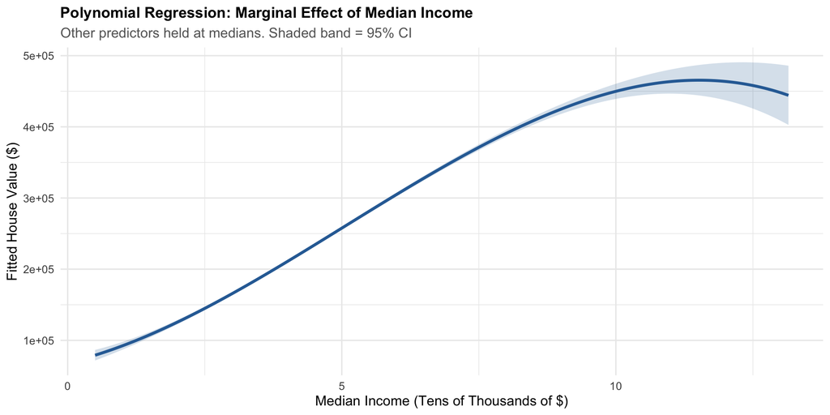

```r
income_grid <- data.frame(
  median_income            = seq(min(train_sc$median_income), max(train_sc$median_income), length = 200),
  latitude                 = median(train_sc$latitude),
  longitude                = median(train_sc$longitude),
  housing_median_age       = median(train_sc$housing_median_age),
  rooms_per_household      = median(train_sc$rooms_per_household),
  bedrooms_per_room        = median(train_sc$bedrooms_per_room),
  population_per_household = median(train_sc$population_per_household)
)

income_pred <- predict(poly_model, newdata = income_grid, interval = "confidence")
income_grid$fit  <- income_pred[, "fit"]
income_grid$lwr  <- income_pred[, "lwr"]
income_grid$upr  <- income_pred[, "upr"]

# Back-transform income from scaled to original for labelling
income_grid$income_orig <- as.numeric(
  (income_grid$median_income * preproc_all$std["median_income"]) +
  preproc_all$mean["median_income"]
)

# Plotting...
ggplot(income_grid, aes(x = income_orig)) +
  geom_ribbon(aes(ymin = lwr, ymax = upr), fill = "#2e6da4", alpha = 0.2) +
  geom_line(aes(y = fit), color = "#2e6da4", linewidth = 1.2) +
  labs(
    title    = "Polynomial Regression: Marginal Effect of Median Income",
    subtitle = "Other predictors held at medians. Shaded band = 95% CI",
    x = "Median Income (Tens of Thousands of $)",
    y = "Fitted House Value ($)"
  )
```

- Between medians $20,000 and $70,000, there was a `linear` increase in the house value and as the median income increases it reached a ceiling of approximately $450,000. This explains the natural phenomenon that when people’s income increases, they tend to live in better and more expensive houses. The ceiling at the top is also a natural phenomenon whereby house prices can only climb so high.

## 7.3 Step Function Regression

**Theoretical basis** Step functions partition the range of a predictor into $K$ bins, fitting a constant in each:

$$y_i = \beta_0 + \beta_1 C_1(x_i) +
\beta_2 C_2(x_i) + \cdots + \beta_K C_K(x_i) +
\varepsilon_i$$

where $C_k(x) = \mathbf{1}(c_{k-1} \le x < c_k)$. Cuts are placed at **quartiles** of each predictor.

```r
train_step <- train_sc %>%
  mutate(
    income_step = cut(median_income, breaks = quantile(median_income, probs = 0:4/4),
                      labels = c("Q1", "Q2", "Q3", "Q4"), include.lowest = TRUE),
    lat_step    = cut(latitude,      breaks = quantile(latitude,      probs = 0:4/4),
                      labels = c("Q1", "Q2", "Q3", "Q4"), include.lowest = TRUE),
    lon_step    = cut(longitude,     breaks = quantile(longitude,     probs = 0:4/4),
                      labels = c("Q1", "Q2", "Q3", "Q4"), include.lowest = TRUE),
    age_step    = cut(housing_median_age, breaks = quantile(housing_median_age, probs = 0:3/3),
                      labels = c("Tertile1", "Tertile2", "Tertile3"), include.lowest = TRUE)
  )

income_breaks <- quantile(train_sc$median_income, probs = 0:4/4)
income_breaks[1] <- -Inf; income_breaks[5] <- Inf

lat_breaks <- quantile(train_sc$latitude, probs = 0:4/4)
lat_breaks[1] <- -Inf; lat_breaks[5] <- Inf

lon_breaks <- quantile(train_sc$longitude, probs = 0:4/4)
lon_breaks[1] <- -Inf; lon_breaks[5] <- Inf

age_breaks <- quantile(train_sc$housing_median_age, probs = 0:3/3)
age_breaks[1] <- -Inf; age_breaks[4] <- Inf

test_step <- test_sc %>%
  mutate(
    income_step = cut(median_income, breaks = income_breaks,
                      labels = c("Q1", "Q2", "Q3", "Q4"), include.lowest = TRUE),
    lat_step    = cut(latitude,      breaks = lat_breaks,
                      labels = c("Q1", "Q2", "Q3", "Q4"), include.lowest = TRUE),
    lon_step    = cut(longitude,     breaks = lon_breaks,
                      labels = c("Q1", "Q2", "Q3", "Q4"), include.lowest = TRUE),
    age_step    = cut(housing_median_age, breaks = age_breaks,
                      labels = c("Tertile1", "Tertile2", "Tertile3"), include.lowest = TRUE)
  )

step_model <- lm(
  median_house_value ~
    income_step + lat_step + lon_step + age_step +
    rooms_per_household + bedrooms_per_room + population_per_household,
  data = train_step
)

summary(step_model)
```

```
#>
#> Call:
#> lm(formula = median_house_value ~ income_step + lat_step + lon_step +
#>     age_step + rooms_per_household + bedrooms_per_room + population_per_household,
#>     data = train_step)
#>
#> Residuals:
#>     Min      1Q  Median      3Q     Max
#> -216702  -45139  -10872   33810  378430
#>
#> Coefficients:
#>                           Estimate Std. Error t value Pr(>|t|)
#> (Intercept)               225442.9     4099.0  55.000  < 2e-16 ***
#> income_stepQ2              46059.7     1747.7  26.355  < 2e-16 ***
#> income_stepQ3              83328.0     1909.2  43.645  < 2e-16 ***
#> income_stepQ4             163211.8     2261.8  72.159  < 2e-16 ***
#> lat_stepQ2                 -8617.1     1836.0  -4.693 2.71e-06 ***
#> lat_stepQ3                -77944.9     3115.0 -25.023  < 2e-16 ***
#> lat_stepQ4               -110695.4     3483.2 -31.780  < 2e-16 ***
#> lon_stepQ2                -57977.9     1819.7 -31.862  < 2e-16 ***
#> lon_stepQ3                -79561.9     3214.6 -24.750  < 2e-16 ***
#> lon_stepQ4               -120941.2     3403.4 -35.536  < 2e-16 ***
#> age_stepTertile2            6843.7     1457.7   4.695 2.70e-06 ***
#> age_stepTertile3            6673.7     1620.4   4.118 3.84e-05 ***
#> rooms_per_household         5225.9      687.0   7.606 3.01e-14 ***
#> bedrooms_per_room          11141.8      850.1  13.106  < 2e-16 ***
#> population_per_household   -2287.3      591.9  -3.864 0.000112 ***
#> ---
#> Signif. codes:  0 '***' 0.001 '**' 0.01 '*' 0.05 '.' 0.1 ' ' 1
#>
#> Residual standard error: 67400 on 12975 degrees of freedom
#> Multiple R-squared:  0.4996, Adjusted R-squared:  0.4991
#> F-statistic: 925.4 on 14 and 12975 DF,  p-value: < 2.2e-16
```

```r
step_preds <- predict(step_model, newdata = test_step)
step_metrics <- calc_metrics(actual = y_test, predicted = step_preds, model_name = "Step Function")

all_metrics[[3]] <- step_metrics
all_preds[["Step"]] <- step_preds

print(step_metrics)
```

```
#> # A tibble: 1 × 4
#>   Model           RMSE    MAE    R2
#>   <chr>          <dbl>  <dbl> <dbl>
#> 1 Step Function 69298. 52673. 0.475
```

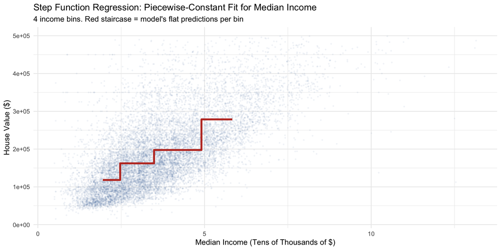

```r
train_step$income_orig <- as.numeric(
  (train_step$median_income * preproc_all$std["median_income"]) +
  preproc_all$mean["median_income"]
)

step_income_df <- train_step %>%
  group_by(income_step) %>%
  summarise(
    mean_income  = mean(median_income),
    mean_value   = mean(median_house_value),
    fitted_value = mean(fitted(step_model)[cur_group_rows()])
  ) %>%
  mutate(
    mean_income_orig = as.numeric((mean_income * preproc_all$std["median_income"]) + preproc_all$mean["median_income"])
  )

ggplot(train_step, aes(x = income_orig, y = median_house_value)) +
  geom_point(alpha = 0.05, color = "#2e6da4", size = 0.5) +
  geom_step(data = step_income_df, aes(x = mean_income_orig, y = fitted_value),
            color = "#c0392b", linewidth = 1.3, direction = "mid") +
  labs(
    title    = "Step Function Regression: Piecewise-Constant Fit for Median Income",
    subtitle = "4 income bins. Red staircase = model's flat predictions per bin",
    x = "Median Income (Tens of Thousands of $)",
    y = "House Value ($)"
  ) +
  theme_minimal()
```

- Due to no natural breakpoints (quartiles), several house values were categorized wrongly.